# Analytics Edge: Unit 7 - Visualization for Law and Order

Sulman Khan

October 26, 2018

## The Analytical Policeman

### The Analytical Policeman

- The explosion of computerized data affects all parts of society, including law and order
- In the past, human judgement and experience was the only tool in identifying patterns in criminal behavior
- Police forces around the US and the world are augmenting human judgement with analytics - sometimes describes as **“predictive”**

### Example: Los Angeles Police Dept.

“I’m not going to get more money. I’m not going to get more cops. I have to be better at using what I have, and that’s what **predictive policing** is about… If this old street cop can change the way that he thinks about this stuff, then I know that my [officers] can do the same.”

### The Role of Analytics

- The analytical tools you have learned in this class can be used to make these “predictive policing” models
- However,$\color{red}{\text{communicating}}$ the results of these models is essential - a $\color{blue}{\text{linear regression}}$ output while table will not be of use to a $\color{red}{\text{policewoman on patrol}}$
- Visualization bridges the gap between $\color{blue}{\text{the data and mathematics}}$ and the $\color{red}{\text{end user}}$

### Understanding the Past

- Before we even consider a predictive model, we should try to understand the historical data
- Many cities in the US and around the world would provide logs of reported crimes, usually including the time, locations, and nature of the event
- We will use data from Chicago about motor vehicle thefts

### Crime Over Time

- Suppose we wanted to communicate crime patterns over the course of an average week
- We would display daily averages using a line graph, but this does not seem like it would be too useful

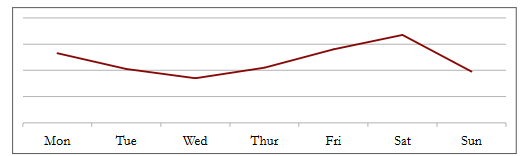

- We can replace our **x-axis** with the **hour of the day**, and have different **line for every day of the week**, but this would be a jumbled mess with **7 lines**!
- We could use no visualization at all, and instead present the information in a table

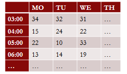

- This is valid but how can we make the table more interesting

### Heatmaps

- **Heatmaps** are a way of visualizing data using three attributes. The **x-axis** and **y-axis** are typically displayed horizontally and vertically. The **third attribute** is represented by shades of color.

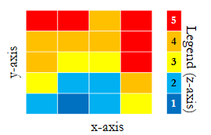

- For example, a **low** number, might be $\color{blue}{\text{blue}}$, and a **high** number might be $\color{red}{\text{red}}$
- We can pick **different color schemes** based on the **type of data** to convey different messages
- The x-axis and y-axis don’t need to be continuous - they can be **categorical**
- We could even combine a heatmap with a **geographical map**

### A Chicao Crime Heatmap

- We will use Chicago motor vehicle theft data to explore patterns of crime
  - Over days of the week
  - Over hours of the day
- We’re interested in the total number of car thefts that occur in any particular hour of a day of the week: over the whole data set.

### Eye on Crime

- Criminal activity-related data often has both components of time and location
- Sometimes all that is required is a line chart, but heatmaps can visualize data that would be too big for a table
- Plotting data on maps is much more effective than a table for location based data, and is eye-catching

### Predicting Policing

- Many police forces are exploiting their databases to focus finite resources on problem areas
- Not only do analytics help improve policework, the outputs are also good communication tools to decision makers in government and to the wider public
- The application of analytics to data like this is new and growing, with companies like PredPol and Palantir leading the effort.

## The Analytical Policeman in R

#### A Basic Line Plot

```r
# Load our data:
mvt = read.csv("mvt.csv", stringsAsFactors=FALSE)
# Output structure
str(mvt)
```

```
## 'data.frame':    191641 obs. of  3 variables:
##  $ Date     : chr  "12/31/12 23:15" "12/31/12 22:00" "12/31/12 22:00" "12/31/12 22:00" ...
##  $ Latitude : num  41.8 41.9 42 41.8 41.8 ...
##  $ Longitude: num  -87.6 -87.7 -87.8 -87.7 -87.6 ...
```

```r
# Convert the Date variable to a format that R will recognize:
mvt$Date = strptime(mvt$Date, format="%m/%d/%y %H:%M")
# Extract the hour and the day of the week:
mvt$Weekday = weekdays(mvt$Date)
mvt$Hour = mvt$Date$hour
# Let's take a look at the structure of our data again:
str(mvt)
```

```
## 'data.frame':    191641 obs. of  5 variables:
##  $ Date     : POSIXlt, format: "2012-12-31 23:15:00" "2012-12-31 22:00:00" "2012-12-31 22:00:00" "2012-12-31 22:00:00" ...
##  $ Latitude : num  41.8 41.9 42 41.8 41.8 ...
##  $ Longitude: num  -87.6 -87.7 -87.8 -87.7 -87.6 ...
##  $ Weekday  : chr  "Monday" "Monday" "Monday" "Monday" ...
##  $ Hour     : int  23 22 22 22 21 20 20 20 19 18 ...
```

```r
# Create a simple line plot - need the total number of crimes on each day of the week. We can get this information by creating a table:
z = table(mvt$Weekday)
kable(z)
```

| Var1 | Freq |
| --- | --- |
| Friday | 29284 |
| Monday | 27397 |
| Saturday | 27118 |
| Sunday | 26316 |
| Thursday | 27319 |
| Tuesday | 26791 |
| Wednesday | 27416 |

```r
# Save this table as a data frame:
WeekdayCounts = as.data.frame(table(mvt$Weekday))
str(WeekdayCounts)
```

```
## 'data.frame':    7 obs. of  2 variables:
##  $ Var1: Factor w/ 7 levels "Friday","Monday",..: 1 2 3 4 5 6 7
##  $ Freq: int  29284 27397 27118 26316 27319 26791 27416
```

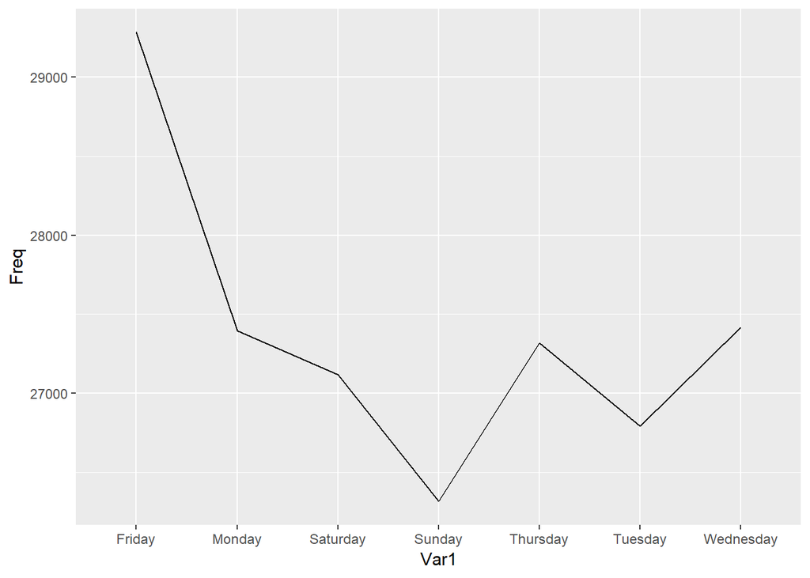

```r
# Load the ggplot2 library:
library(ggplot2)
# Create our plot
ggplot(WeekdayCounts, aes(x=Var1, y=Freq)) + geom_line(aes(group=1))
```

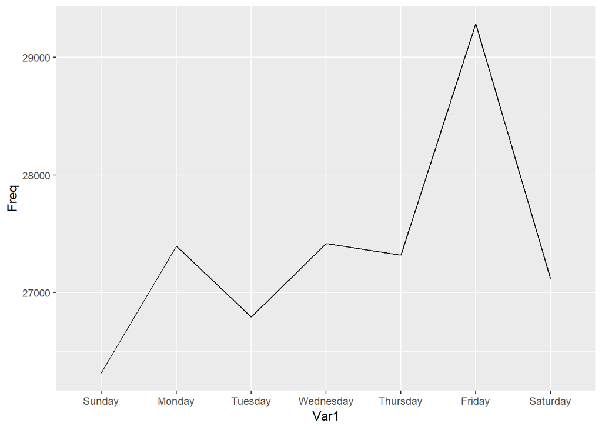

```r
# Make the "Var1" variable an ORDERED factor variable
WeekdayCounts$Var1 = factor(WeekdayCounts$Var1, ordered=TRUE, levels=c("Sunday", "Monday", "Tuesday", "Wednesday", "Thursday", "Friday","Saturday"))
# Try again:
ggplot(WeekdayCounts, aes(x=Var1, y=Freq)) + geom_line(aes(group=1))
```

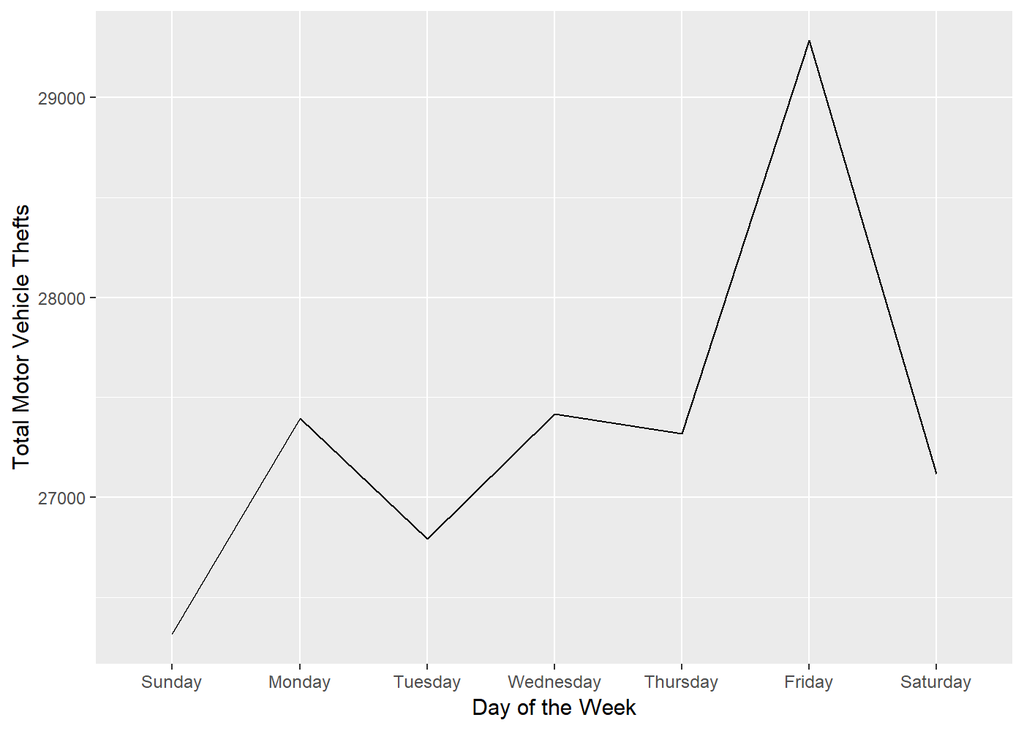

```r
# Change our x and y labels:
ggplot(WeekdayCounts, aes(x=Var1, y=Freq)) + geom_line(aes(group=1)) + xlab("Day of the Week") + ylab("Total Motor Vehicle Thefts")
```

### Adding the Hour of the Day

```r
# Create a counts table for the weekday and hour:
z = table(mvt$Weekday, mvt$Hour)
kable(z)
```

|  | 0 | 1 | 2 | 3 | 4 | 5 | 6 | 7 | 8 | 9 | 10 | 11 | 12 | 13 | 14 | 15 | 16 | 17 | 18 | 19 | 20 | 21 | 22 | 23 |
| --- | --- | --- | --- | --- | --- | --- | --- | --- | --- | --- | --- | --- | --- | --- | --- | --- | --- | --- | --- | --- | --- | --- | --- | --- |
| Friday | 1873 | 932 | 743 | 560 | 473 | 602 | 839 | 1203 | 1268 | 1286 | 938 | 822 | 1207 | 857 | 937 | 1140 | 1165 | 1318 | 1623 | 1652 | 1736 | 1881 | 2308 | 1921 |
| Monday | 1900 | 825 | 712 | 527 | 415 | 542 | 772 | 1123 | 1323 | 1235 | 971 | 737 | 1129 | 824 | 958 | 1059 | 1136 | 1252 | 1518 | 1503 | 1622 | 1815 | 2009 | 1490 |
| Saturday | 2050 | 1267 | 985 | 836 | 652 | 508 | 541 | 650 | 858 | 1039 | 946 | 789 | 1204 | 767 | 963 | 1086 | 1055 | 1084 | 1348 | 1390 | 1570 | 1702 | 2078 | 1750 |
| Sunday | 2028 | 1236 | 1019 | 838 | 607 | 461 | 478 | 483 | 615 | 864 | 884 | 787 | 1192 | 789 | 959 | 1037 | 1083 | 1160 | 1389 | 1342 | 1706 | 1696 | 2079 | 1584 |
| Thursday | 1856 | 816 | 696 | 508 | 400 | 534 | 799 | 1135 | 1298 | 1301 | 932 | 731 | 1093 | 752 | 831 | 1044 | 1131 | 1258 | 1510 | 1537 | 1668 | 1776 | 2134 | 1579 |
| Tuesday | 1691 | 777 | 603 | 464 | 414 | 520 | 845 | 1118 | 1175 | 1174 | 948 | 786 | 1108 | 762 | 908 | 1071 | 1090 | 1274 | 1553 | 1496 | 1696 | 1816 | 2044 | 1458 |
| Wednesday | 1814 | 790 | 619 | 469 | 396 | 561 | 862 | 1140 | 1329 | 1237 | 947 | 763 | 1225 | 804 | 863 | 1075 | 1076 | 1289 | 1580 | 1507 | 1718 | 1748 | 2093 | 1511 |

```r
# Save this to a data frame:
DayHourCounts = as.data.frame(table(mvt$Weekday, mvt$Hour))
# Output structure
str(DayHourCounts)
```

```
## 'data.frame':    168 obs. of  3 variables:
##  $ Var1: Factor w/ 7 levels "Friday","Monday",..: 1 2 3 4 5 6 7 1 2 3 ...
##  $ Var2: Factor w/ 24 levels "0","1","2","3",..: 1 1 1 1 1 1 1 2 2 2 ...
##  $ Freq: int  1873 1900 2050 2028 1856 1691 1814 932 825 1267 ...
```

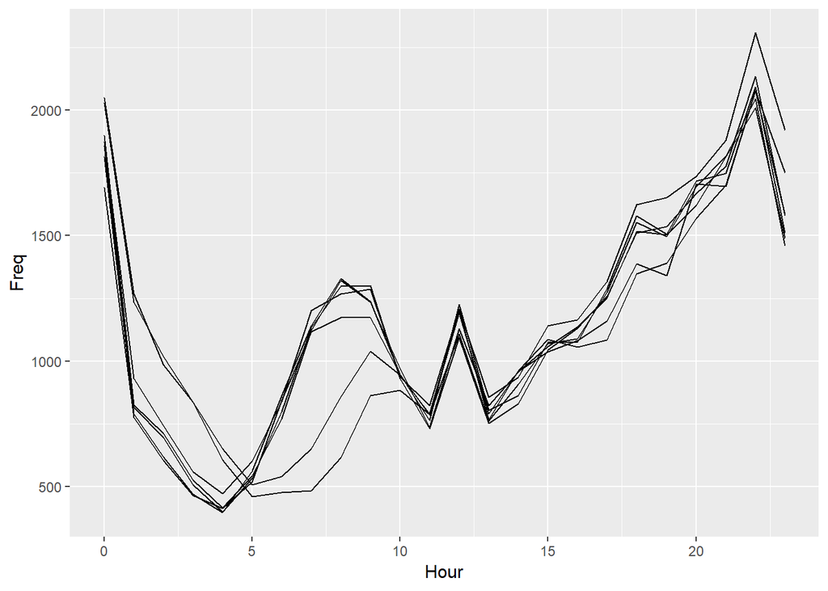

```r
# Convert the second variable, Var2, to numbers and call it Hour:
DayHourCounts$Hour = as.numeric(as.character(DayHourCounts$Var2))
# Create out plot:
ggplot(DayHourCounts, aes(x=Hour, y=Freq)) + geom_line(aes(group=Var1))
```

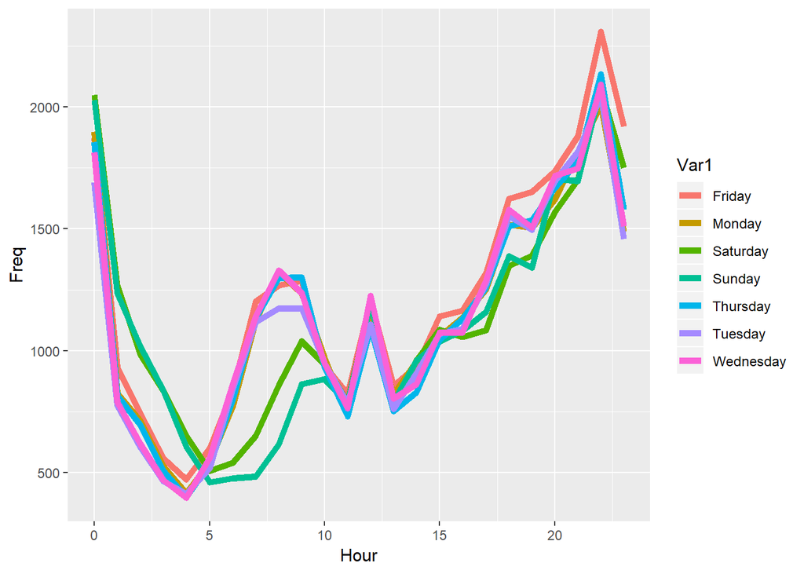

```r
# Change the colors
ggplot(DayHourCounts, aes(x=Hour, y=Freq)) + geom_line(aes(group=Var1, color=Var1), size=2)
```

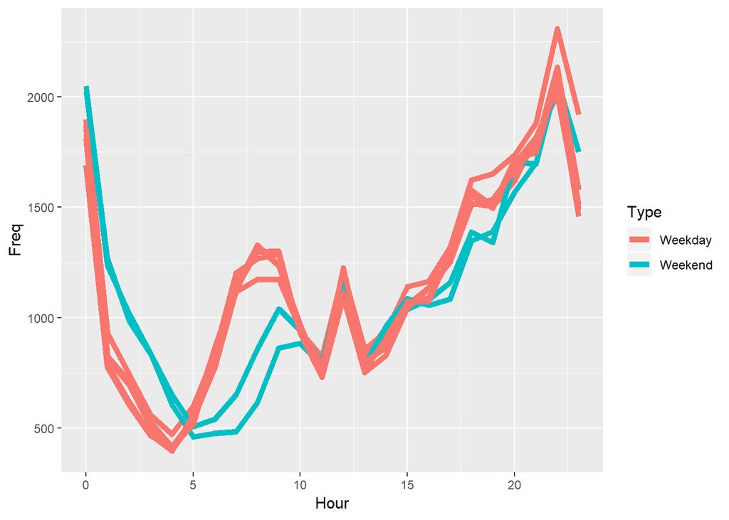

```r
# Separate the weekends from the weekdays:
DayHourCounts$Type = ifelse((DayHourCounts$Var1 == "Sunday") | (DayHourCounts$Var1 == "Saturday"), "Weekend", "Weekday")
# Redo our plot, this time coloring by Type:
ggplot(DayHourCounts, aes(x=Hour, y=Freq)) + geom_line(aes(group=Var1, color=Type), size=2)
```

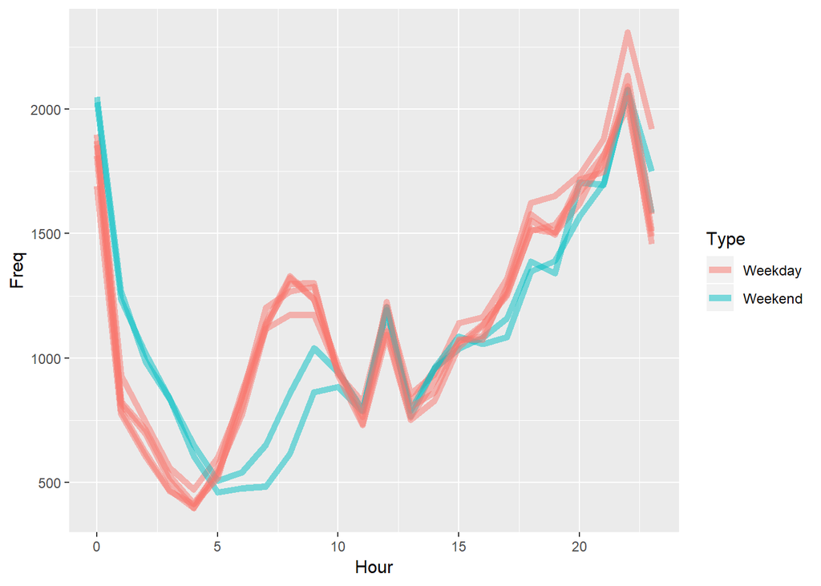

```r
# Make the lines a little transparent:
ggplot(DayHourCounts, aes(x=Hour, y=Freq)) + geom_line(aes(group=Var1, color=Type), size=2, alpha=0.5)
```

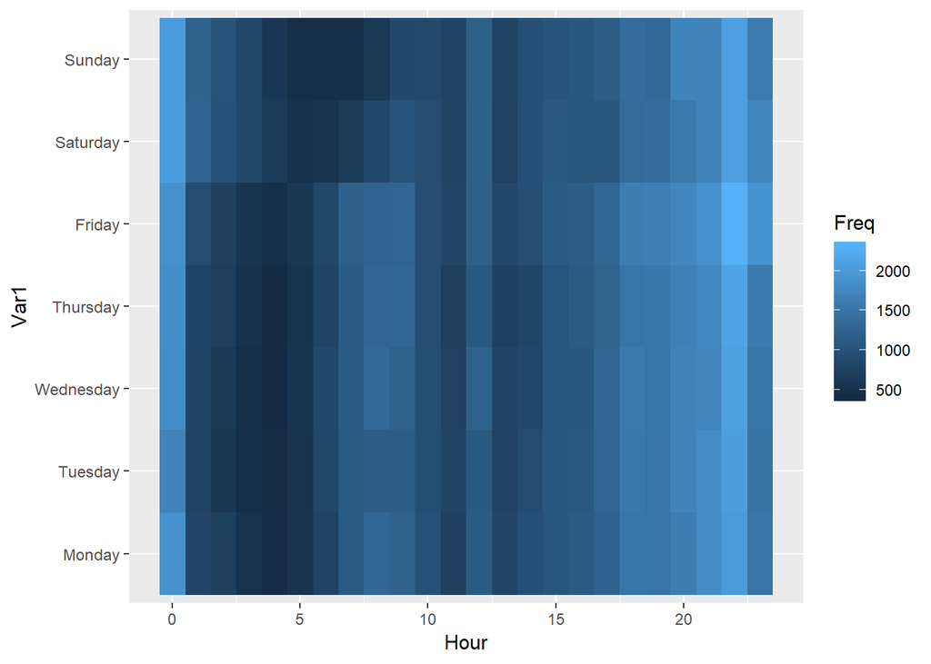

```r
# Fix the order of the days:
DayHourCounts$Var1 = factor(DayHourCounts$Var1, ordered=TRUE, levels=c("Monday", "Tuesday", "Wednesday", "Thursday", "Friday", "Saturday", "Sunday"))
# Make a heatmap:
ggplot(DayHourCounts, aes(x = Hour, y = Var1)) + geom_tile(aes(fill = Freq))
```

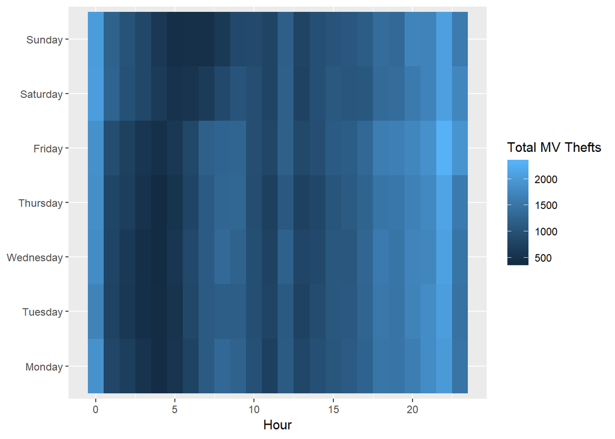

```r
# Change the label on the legend, and get rid of the y-label:
ggplot(DayHourCounts, aes(x = Hour, y = Var1)) + geom_tile(aes(fill = Freq)) + scale_fill_gradient(name="Total MV Thefts") + theme(axis.title.y = element_blank())
```

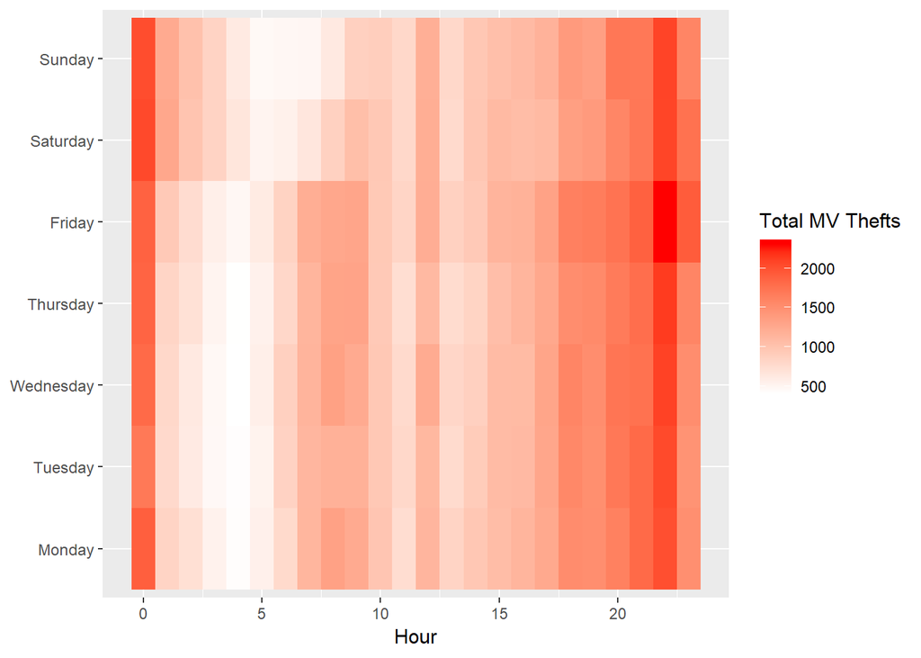

```r
# Change the color scheme
ggplot(DayHourCounts, aes(x = Hour, y = Var1)) + geom_tile(aes(fill = Freq)) + scale_fill_gradient(name="Total MV Thefts", low="white", high="red") + theme(axis.title.y = element_blank())
```

### VIDEO 5 - Maps

[figure not shown]

```r
# Install and load two new packages:
library(maps)
library(devtools)
library(ggmap)
register_google(key = "AIzaSyBlCZXGDK9dN3Vf_N1qdI6mPfFFCA34ubs")
# Load a map of Chicago into R:
chicago = get_map(location = "chicago", zoom = 11)
# Look at the map
ggmap(chicago)
```

[figure not shown]

```r
# Plot the first 100 motor vehicle thefts:
ggmap(chicago) + geom_point(data = mvt[1:100,], aes(x = Longitude, y = Latitude))
```

```r
# Round our latitude and longitude to 2 digits of accuracy, and create a crime counts data frame for each area:
LatLonCounts = as.data.frame(table(round(mvt$Longitude,2), round(mvt$Latitude,2)))
# Subset for Freq > 0
LatLonCounts2 = subset(LatLonCounts, Freq > 0)
#Output structure
str(LatLonCounts)
```

```
## 'data.frame':    1638 obs. of  3 variables:
##  $ Var1: Factor w/ 42 levels "-87.93","-87.92",..: 1 2 3 4 5 6 7 8 9 10 ...
##  $ Var2: Factor w/ 39 levels "41.64","41.65",..: 1 1 1 1 1 1 1 1 1 1 ...
##  $ Freq: int  0 0 0 0 0 0 0 0 0 0 ...
```

```r
str(LatLonCounts2)
```

```
## 'data.frame':    686 obs. of  3 variables:
##  $ Var1: Factor w/ 42 levels "-87.93","-87.92",..: 33 40 32 33 34 35 38 39 40 41 ...
##  $ Var2: Factor w/ 39 levels "41.64","41.65",..: 1 1 2 2 2 2 2 2 2 2 ...
##  $ Freq: int  3 1 54 60 28 1 8 63 81 8 ...
```

[figure not shown]

```r
# Convert our Longitude and Latitude variable to numbers:
LatLonCounts$Long = as.numeric(as.character(LatLonCounts$Var1))
LatLonCounts$Lat = as.numeric(as.character(LatLonCounts$Var2))
LatLonCounts2$Long = as.numeric(as.character(LatLonCounts2$Var1))
LatLonCounts2$Lat = as.numeric(as.character(LatLonCounts2$Var2))
# Plot these points on our map:
ggmap(chicago) + geom_point(data = LatLonCounts, aes(x = Long, y = Lat, color = Freq, size=Freq))
```

[figure not shown]

```r
# Change the color scheme:
ggmap(chicago) + geom_point(data = LatLonCounts, aes(x = Long, y = Lat, color = Freq, size=Freq)) + scale_colour_gradient(low="yellow", high="red")
```

[figure not shown]

```r
# We can also use the geom_tile geometry
ggmap(chicago) + geom_tile(data = LatLonCounts, aes(x = Long, y = Lat, alpha = Freq), fill="red")
```

[figure not shown]

```r
#freq > 0
ggmap(chicago) + geom_tile(data=LatLonCounts2, aes(x = Long, y = Lat, alpha=Freq), fill="red")
```

### Geographical Map on US

```r
# Load our data:
murders = read.csv("murders.csv")
# Output structure
str(murders)
```

```
## 'data.frame':    51 obs. of  6 variables:
##  $ State            : Factor w/ 51 levels "Alabama","Alaska",..: 1 2 3 4 5 6 7 8 9 10 ...
##  $ Population       : int  4779736 710231 6392017 2915918 37253956 5029196 3574097 897934 601723 19687653 ...
##  $ PopulationDensity: num  94.65 1.26 57.05 56.43 244.2 ...
##  $ Murders          : int  199 31 352 130 1811 117 131 48 131 987 ...
##  $ GunMurders       : int  135 19 232 93 1257 65 97 38 99 669 ...
##  $ GunOwnership     : num  0.517 0.578 0.311 0.553 0.213 0.347 0.167 0.255 0.036 0.245 ...
```

```r
# Load the map of the US
statesMap = map_data("state")
# Output structure
str(statesMap)
```

```
## 'data.frame':    15537 obs. of  6 variables:
##  $ long     : num  -87.5 -87.5 -87.5 -87.5 -87.6 ...
##  $ lat      : num  30.4 30.4 30.4 30.3 30.3 ...
##  $ group    : num  1 1 1 1 1 1 1 1 1 1 ...
##  $ order    : int  1 2 3 4 5 6 7 8 9 10 ...
##  $ region   : chr  "alabama" "alabama" "alabama" "alabama" ...
##  $ subregion: chr  NA NA NA NA ...
```

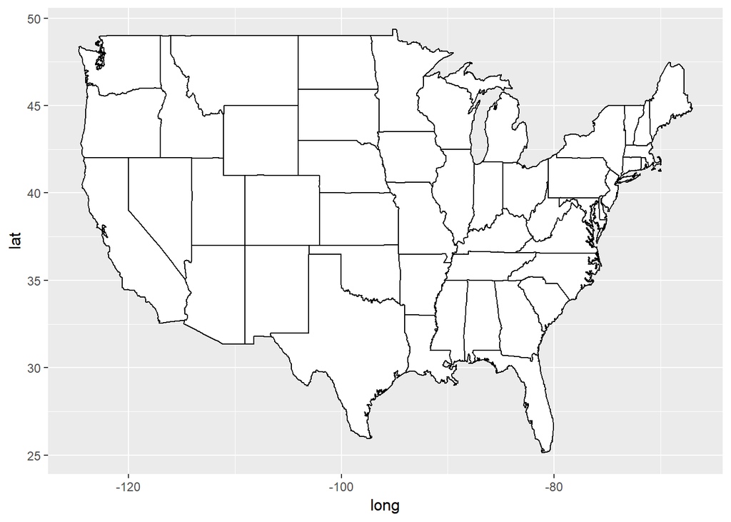

```r
# Plot the map:
ggplot(statesMap, aes(x = long, y = lat, group = group)) + geom_polygon(fill = "white", color = "black")
```

```r
# Create a new variable called region with the lowercase names to match the statesMap:
murders$region = tolower(murders$State)
# Join the statesMap data and the murders data into one dataframe:
murderMap = merge(statesMap, murders, by="region")
str(murderMap)
```

```
## 'data.frame':    15537 obs. of  12 variables:
##  $ region           : chr  "alabama" "alabama" "alabama" "alabama" ...
##  $ long             : num  -87.5 -87.5 -87.5 -87.5 -87.6 ...
##  $ lat              : num  30.4 30.4 30.4 30.3 30.3 ...
##  $ group            : num  1 1 1 1 1 1 1 1 1 1 ...
##  $ order            : int  1 2 3 4 5 6 7 8 9 10 ...
##  $ subregion        : chr  NA NA NA NA ...
##  $ State            : Factor w/ 51 levels "Alabama","Alaska",..: 1 1 1 1 1 1 1 1 1 1 ...
##  $ Population       : int  4779736 4779736 4779736 4779736 4779736 4779736 4779736 4779736 4779736 4779736 ...
##  $ PopulationDensity: num  94.7 94.7 94.7 94.7 94.7 ...
##  $ Murders          : int  199 199 199 199 199 199 199 199 199 199 ...
##  $ GunMurders       : int  135 135 135 135 135 135 135 135 135 135 ...
##  $ GunOwnership     : num  0.517 0.517 0.517 0.517 0.517 0.517 0.517 0.517 0.517 0.517 ...
```

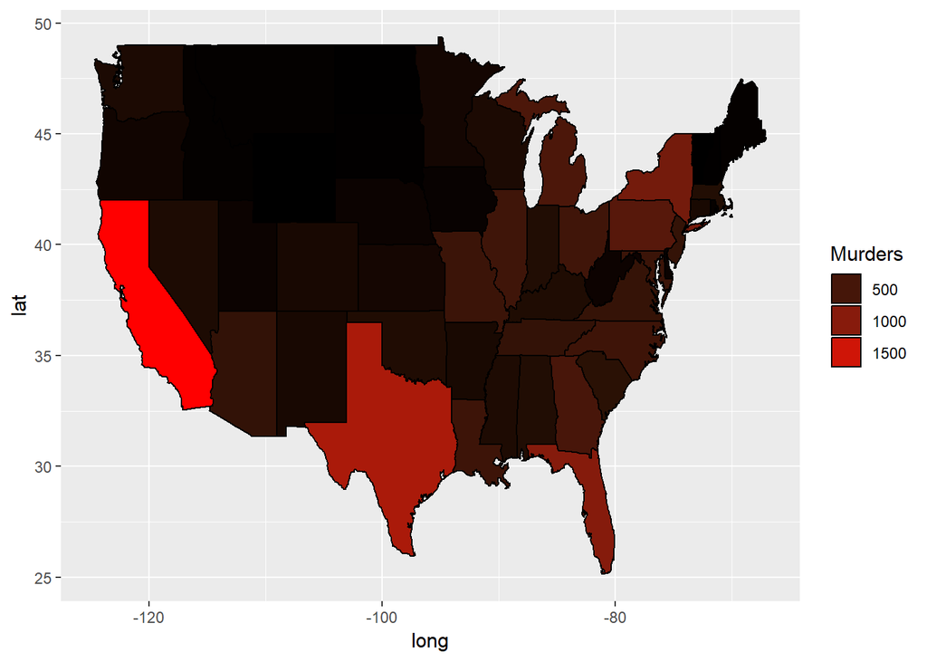

```r
# Plot the number of murder on our map of the United States:
ggplot(murderMap, aes(x = long, y = lat, group = group, fill = Murders)) + geom_polygon(color = "black") + scale_fill_gradient(low = "black", high = "red", guide = "legend")
```

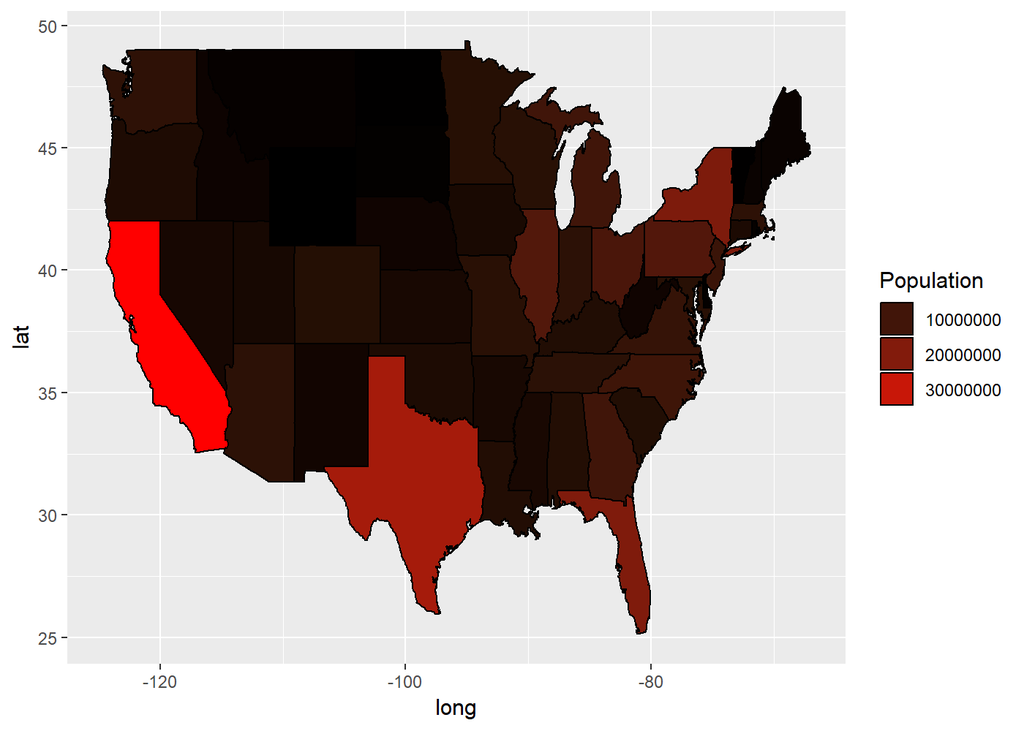

```r
# Plot a map of the population:
ggplot(murderMap, aes(x = long, y = lat, group = group, fill = Population)) + geom_polygon(color = "black") + scale_fill_gradient(low = "black", high = "red", guide = "legend")
```

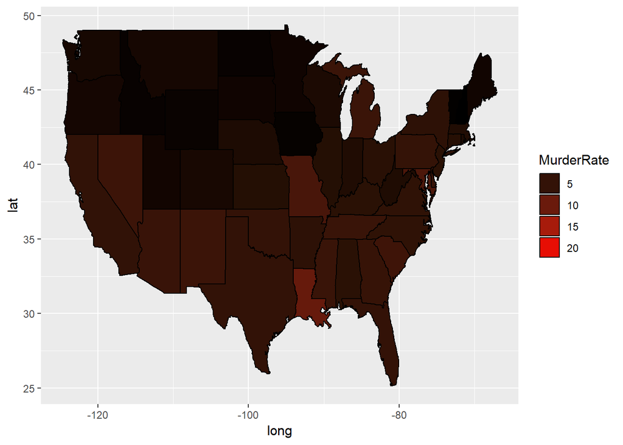

```r
# Create a new variable that is the number of murders per 100,000 population:
murderMap$MurderRate = murderMap$Murders / murderMap$Population * 100000
# Redo our plot with murder rate:
ggplot(murderMap, aes(x = long, y = lat, group = group, fill = MurderRate)) + geom_polygon(color = "black") + scale_fill_gradient(low = "black", high = "red", guide = "legend")
```

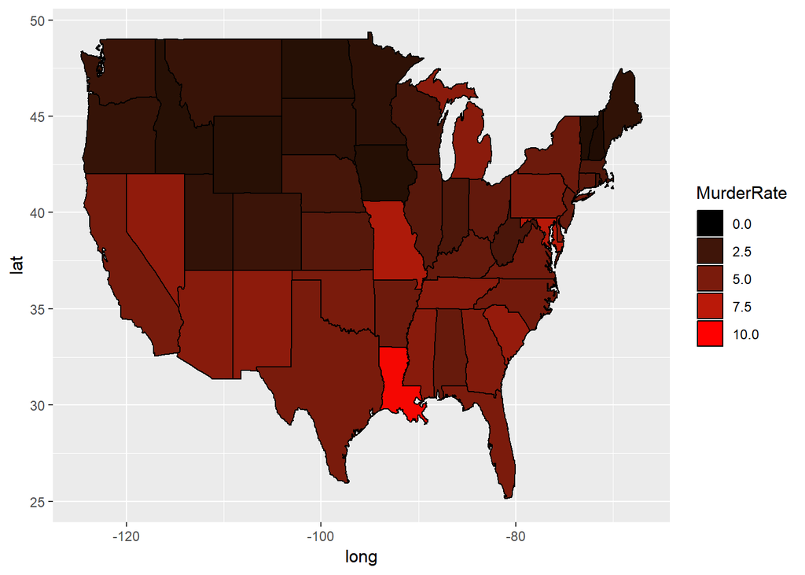

```r
# Redo the plot, removing any states with murder rates above 10:
ggplot(murderMap, aes(x = long, y = lat, group = group, fill = MurderRate)) + geom_polygon(color = "black") + scale_fill_gradient(low = "black", high = "red", guide = "legend", limits = c(0,10))
```